# Smoothing Intro

26 June, 2019

# Packages

```r
library(tidyverse) # general data cleanup
library(magrittr) # pipe for function nesting
library(here) # for working directory help

library(sp) # spatial data plotting and classes
library(rgdal) # working with coordinate reference systems
library(rgeos) # topology operations on geometric objects
library(spdep) # adjacency matrix generation
library(RColorBrewer) # Allows for creation of color ramp
```

# Read in the .shp file

The .shp file is read in by *rgdal::readOGR*. The *here::here* function is used to make sure if this file is knitted from somewhere other than the project root, then the data can still be properly referenced.

```r
# Create SpatialPolygonsDataFrame
gaCounty <- readOGR(here("Data"),
                    "County",
                    verbose = F)

# Set ID attribute of polygons to their "natural" names instead of numbers

# Georgia Counties Named
gaCounty_n <- spChFIDs(
  obj = gaCounty,
  x = as.character(gaCounty$NAME))

# Read in the aggregated data
popData <- readxl::read_xlsx("Data/PopData.xlsx") %>%
  mutate(MortRate = Mortality / Population * 1000) %>%
  arrange(match(County, as.character(gaCounty$NAME))) %>%
  data.frame()

row.names(popData) <- as.character(gaCounty$NAME)
```

# Create the *nb* object

Here the SpatialPolygonsDataFrame is used to determine county adjacency. Luckily, Georgia doesn’t have any islands that are counties or weird boarders caused by holes in the map. The *spdep* package uses boundary proximity to determine neighbor status. Interestingly, indicating queen adjacency (only one shared point between counties required for adjacency) does make a difference in Georgia’s case. Emanuel county has a few neighbors that only touch it at a point. In this case, queen adjacency is set to *F*, because those small boarders don’t seem to indicate similarity the way a large boarder might.

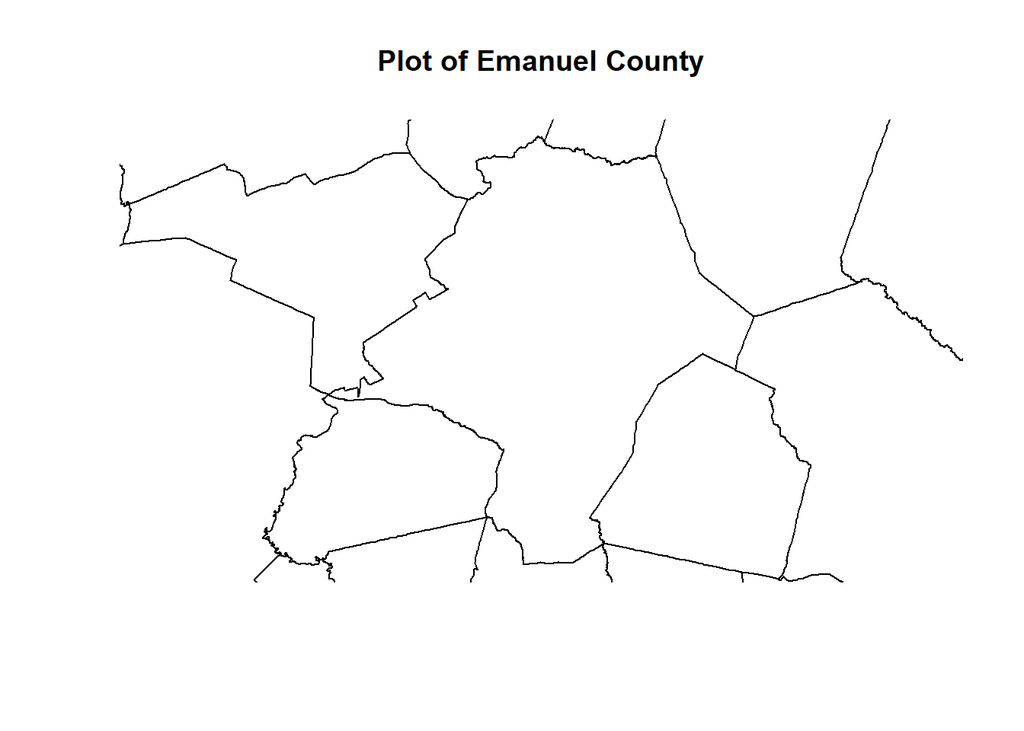

```r
# Create spatial neighbors
gaCounty_nb <- poly2nb(gaCounty_n, queen=F) # Queen contingency MATTERS see emanuel county

emanuelBbox <- SpatialPolygons(gaCounty_n@polygons[match("Emanuel", as.character(gaCounty$NAME))])@bbox

plot(gaCounty_n, xlim = emanuelBbox["x",], ylim = emanuelBbox["y",], main = "Plot of Emanuel County")
```

```r
# plot(gaCounty_n[match("Emanuel", as.character(gaCounty$NAME))],
#      add = T,
#      border = "red")
```

# Class investigation

For some reason, the *nb* objects are S3 and the *Spatial*DataFrame* objects are S4. Understanding how to access the attributes of both will improve the ease with which these objects are accessed/manipulated.

```r
# Shows that this is just a list written in S4
pryr::otype(gaCounty_nb)
```

```
## [1] "S3"
```

```r
str(gaCounty_nb[1:5])
```

```
## List of 5
##  $ : int [1:2] 2 11
##  $ : int [1:4] 1 7 11 12
##  $ : int [1:5] 4 7 10 13 16
##  $ : int [1:4] 3 5 10 15
##  $ : int [1:4] 4 6 8 15
```

```r
# Shows the attributes of the object
# attributes(gaCounty_nb)

summary(gaCounty_nb)
```

```
## Neighbour list object:
## Number of regions: 159
## Number of nonzero links: 834
## Percentage nonzero weights: 3.29892
## Average number of links: 5.245283
## Link number distribution:
##
##  1  2  3  4  5  6  7  8 10
##  1  4 12 32 40 39 23  7  1
## 1 least connected region:
## Dade with 1 link
## 1 most connected region:
## Fulton with 10 links
```

```r
# Annoyingly, nb objects are S3 whereas Spatial*DataFrame objects are S4
pryr::otype(gaCounty_n)
```

```
## [1] "S4"
```

```r
getClass(class(gaCounty_n))
```

```
## Class "SpatialPolygonsDataFrame" [package "sp"]
##
## Slots:
##
## Name:         data    polygons   plotOrder        bbox proj4string
## Class:  data.frame        list     integer      matrix         CRS
##
## Extends:
## Class "SpatialPolygons", directly
## Class "Spatial", by class "SpatialPolygons", distance 2
## Class "SpatialPolygonsNULL", by class "SpatialPolygons", distance 2, with explicit coerce
```

# Adjacency smoothing

The following code includes a loop that completes adjacency smoothing for the SpatialPolygonsDataFrame. The result is a map where the mortality rate for a county $i$ is the mean of its own mortality rate and the rates of its adjacent counties.

```r
num <- popData$Mortality
denom <- popData$Population

# Creates an empty numeric vector to hold the values of the smoothing
aggData <- data.frame(MortRateSmooth = numeric(length(gaCounty_nb)))

# Add row names to the data frame for later merging
row.names(aggData) <- row.names(gaCounty_n)

# Combine the aggregate data with the original population data
gaCountyData <- cbind(popData,aggData)

# Cycle through rows of neighbors taking proportion of cases in queen
# neighbors
for(i in 1:length(gaCounty_nb)) {

  indeces <- c(i,gaCounty_nb[[i]])

  # gaCountyData$MortRateSmooth[i] <- sum(num[indeces]) / sum(denom[indeces]) * 1000
  gaCountyData$MortRateSmooth[i] <- mean(num[indeces] / denom[indeces]) * 1000

  }

# confirmation, Catoosa County
# (14 / 68939 + # Dade
# 24 /  66550 + # Walker
# 16 / 104658  # Whitfield
# ) / 3


# Add the data with tht new vector to gaCounty
gaCounty_df <- SpatialPolygonsDataFrame(gaCounty_n, gaCountyData)

gaCounty_df$MortRate <- ifelse(gaCounty_df$MortRate == 0, NA_real_, gaCounty_df$MortRate)
```

# Raw data and smoothed data plot

The raw mortality rates are plotted below. To emphasize the difficulty of working with potentially small numerators, the counties with 0 oversdose deaths are plotted with no coloring. The adjacency smoothed map shows a more continuous estimate of risk in that there are no counties that show $0$ risk of drug-related mortality. The smoothing also helped reduce the range of the mortality rates which was attributable to counties having small denominators more than it was attributable to extreme amounts of risk. The distributions of these values are shown in the bottom plot.

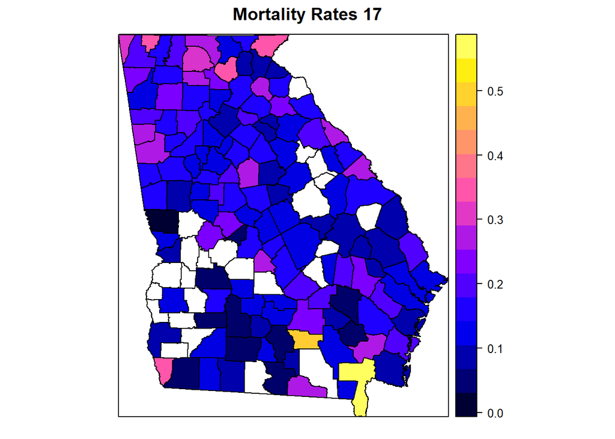

```r
p <- spplot(gaCounty_df, zcol = c("MortRate"),
            main = "Mortality Rates 17")
p
```

```r
# summary(gaCounty_df@data$MortRate)
```

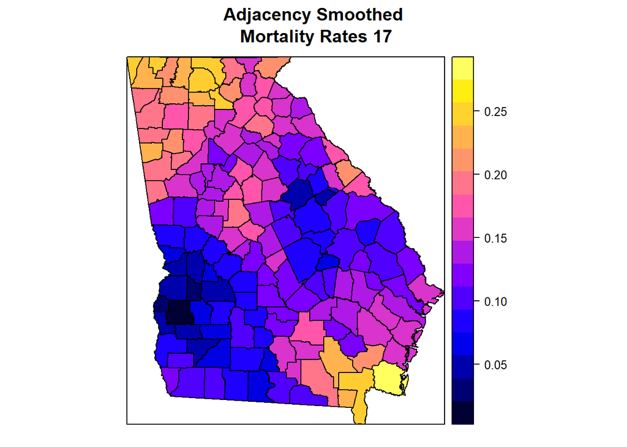

```r
ps <- spplot(gaCounty_df, zcol = c("MortRateSmooth"), main = "Adjacency Smoothed\n Mortality Rates 17")
ps
```

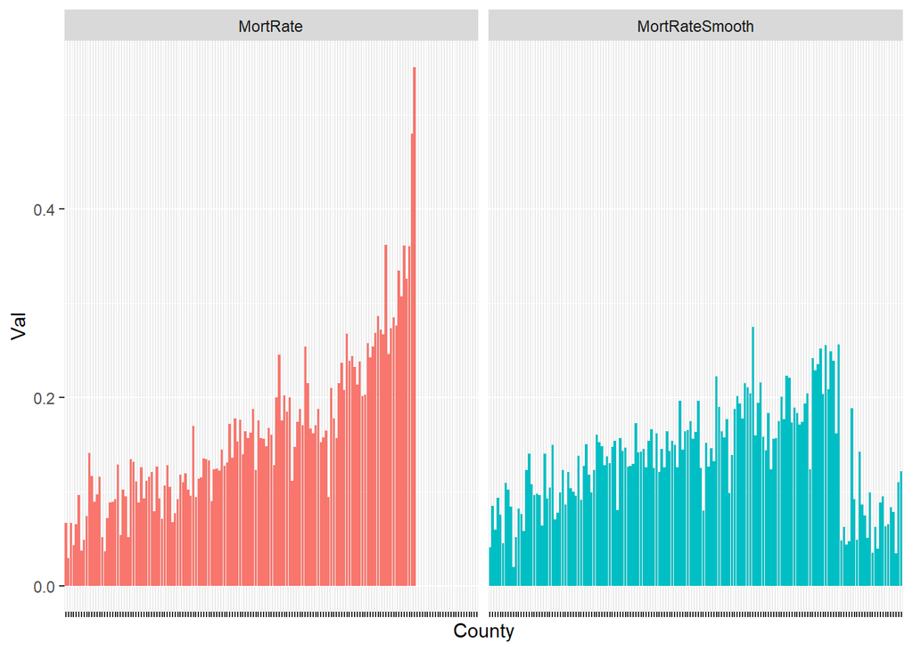

```r
# summary(gaCounty_df@data$MortRateSmooth)

gaCounty_df@data %>%
  gather(Type, Val, MortRate, MortRateSmooth) %>%
  mutate(County = fct_reorder(County, Val)) %>%
  replace_na(list(Val = 0)) %>%
  ggplot(aes(x = County, y = Val, fill = Type)) +
  geom_bar(stat = "identity") +
  theme(legend.position = "None") +
  facet_grid(rows  = ~Type) +
  scale_x_discrete(labels = NULL)
```

# Try a different weighting algorithm

The weights $w_i$ are the inverse distance between the centroid of a county $i$ and its neighbor. I set the value of the distance between region $i$ itself to be the non-zero minimum. There should probably be a heavier weight applied to the value in the county $i$, but this suffices as proof of concept.

```r
gaCountyData$MortRateSmoothDist <- numeric(length = length(gaCounty_nb))

# Find distance between two polygons

dist_matrix <- as.matrix(dist(gCentroid(gaCounty_df, byid = T)@coords))

nonZero_min <- function(x) min(subset(x, x !=0))

for(i in 1:length(gaCounty_nb)) {

  indeces <- c(i,gaCounty_nb[[i]])

  w_i <- dist_matrix[indeces, i]
  w_i[1] <- nonZero_min(w_i)

  gaCountyData$MortRateSmoothDist[i] <- sum((1 / w_i) * (num[indeces] / denom[indeces]) * 1000) /
    sum((1 / w_i)) # *
    # 1000 # Removed times 1000 because we are no longer in incidence measures

  }

# Add the data with tht new vector to gaCounty
gaCounty_df <- SpatialPolygonsDataFrame(gaCounty_n, gaCountyData)

gaCounty_df$MortRate <- ifelse(gaCounty_df$MortRate == 0, NA_real_, gaCounty_df$MortRate)
```

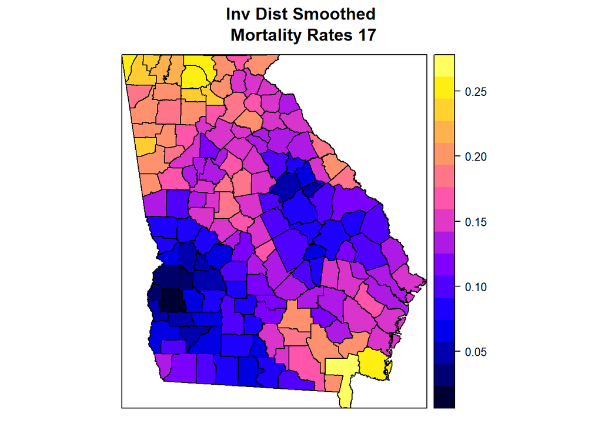

```r
ps_i <- spplot(gaCounty_df, zcol = c("MortRateSmoothDist"), main = "Inv Dist Smoothed\n Mortality Rates 17")
ps_i
```

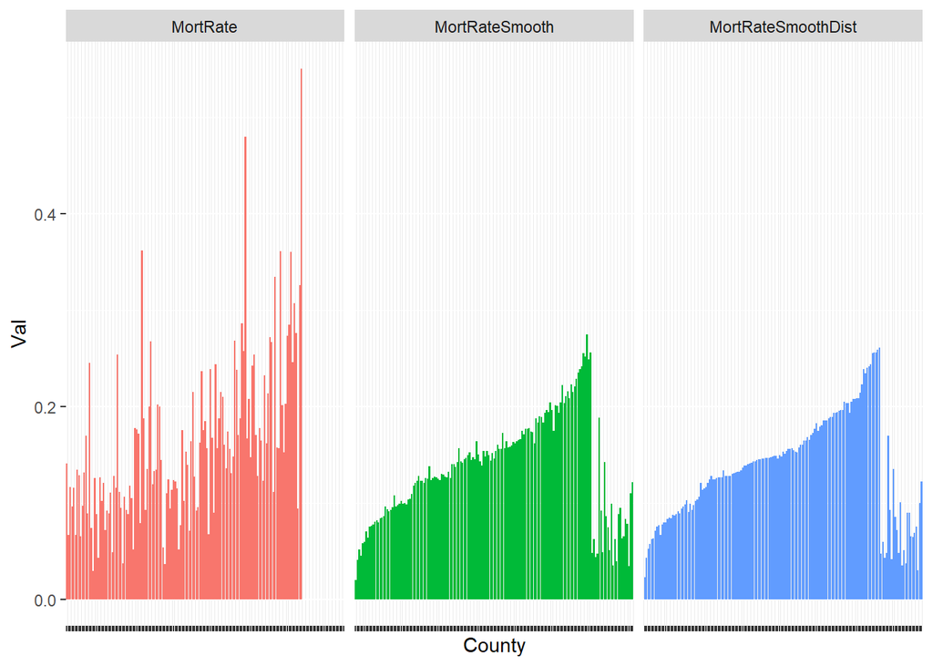

```r
# summary(gaCounty_df@data$MortRateSmooth)

gaCounty_df@data %>%
  gather(Type, Val, MortRate, MortRateSmooth, MortRateSmoothDist) %>%
  mutate(County = fct_reorder(County, Val)) %>%
  replace_na(list(Val = 0)) %>%
  ggplot(aes(x = County, y = Val, fill = Type)) +
  geom_bar(stat = "identity") +
  theme(legend.position = "None") +
  facet_grid(rows  = ~Type, scales = "free_y") +
  scale_x_discrete(labels = NULL)
```

# Smoothing methods compared

The following group of plots shows three different modifications of the original drug-related mortality data. An additional plot was added here where the top two drug-related mortality rates were replaced with NA values to help reduce the color range in the map, making other high mortality rates easier to identify. Before moving on to other methods, it may be useful to ask around the department and do some reading about the drug-related outcomes in these regions to confirm that these maps are demonstrating realistic patterns.

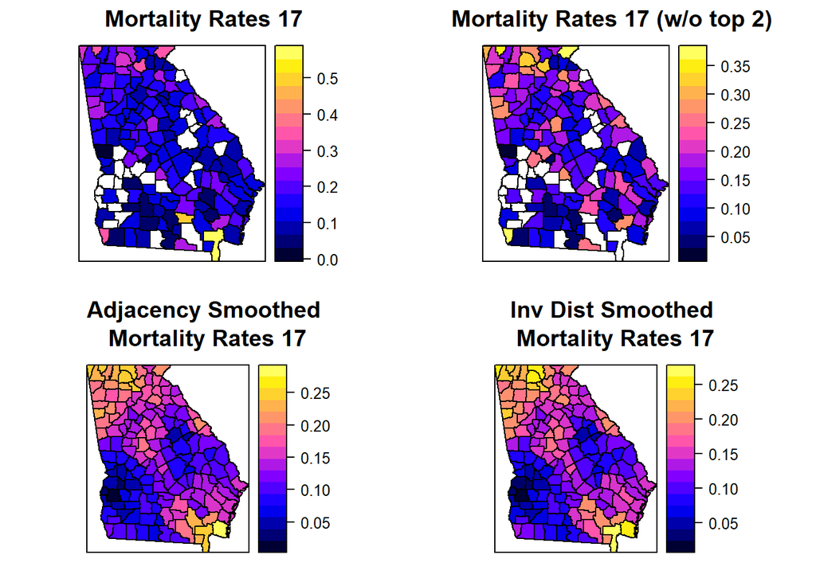

```r
MortRateNA <- gaCounty_df@data$MortRate

MortRateNA[gaCounty_df$County %in% c("Charlton", "Atkinson")] <- NA

gaCounty_df$MortRateNA <- MortRateNA

# No Charlton or Atkinson
p_nca <- spplot(gaCounty_df, zcol = c("MortRateNA"), main = "Mortality Rates 17 (w/o top 2)")

gridExtra::grid.arrange(p,p_nca,ps,ps_i, ncol = 2)
```

# Add Roads/Change Color Ramp

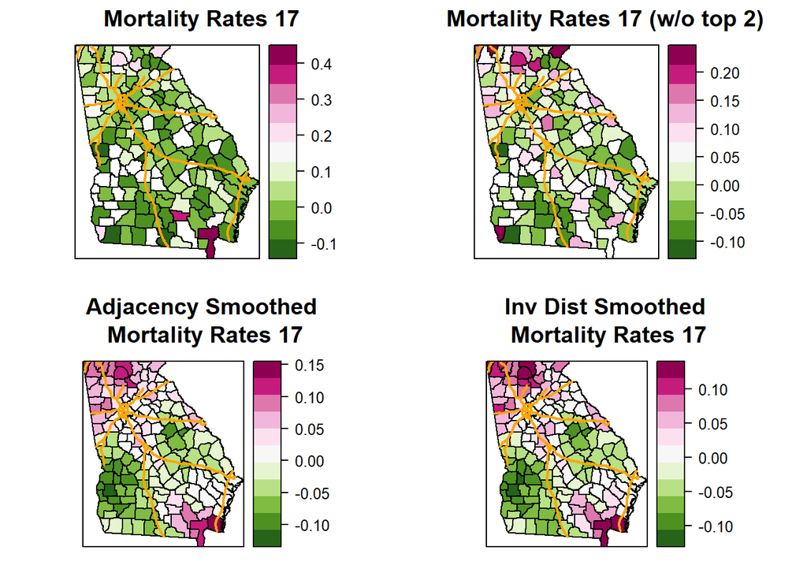

```r
gaRoads <- readOGR(here("Data"), "OASIS_interstates_ver4",
                   verbose = F)

spplot_ga <- function(vr, nm) {

  spdf <- gaCounty_df

  spdf_mean <- mean(replace(gaCounty_df@data[,"MortRate"],
                            is.na(gaCounty_df@data[,"MortRate"]),
                            0)
                      )

  spdf@data[, vr] <- spdf@data[, vr] - spdf_mean

  spplot(spdf, zcol = c(vr),
            main = nm,
            col.regions = rev(cr),
            cuts = 10,
            sp.layout = list("sp.lines", gaRoads,
                             col = "Orange", lwd = 2))
}

# Raw
cr <- brewer.pal(11, "PiYG")
p <- spplot_ga("MortRate", "Mortality Rates 17")

# No Charlton or Atkinson
p_nca <- spplot_ga("MortRateNA", "Mortality Rates 17 (w/o top 2)")

# Adjacency
ps <- spplot_ga("MortRateSmooth", "Adjacency Smoothed\n Mortality Rates 17")

# Inv Distance
ps_i <- spplot_ga("MortRateSmoothDist", "Inv Dist Smoothed\n Mortality Rates 17")

gridExtra::grid.arrange(p,p_nca,ps,ps_i, ncol = 2)
```

# Add Bayes Estimates

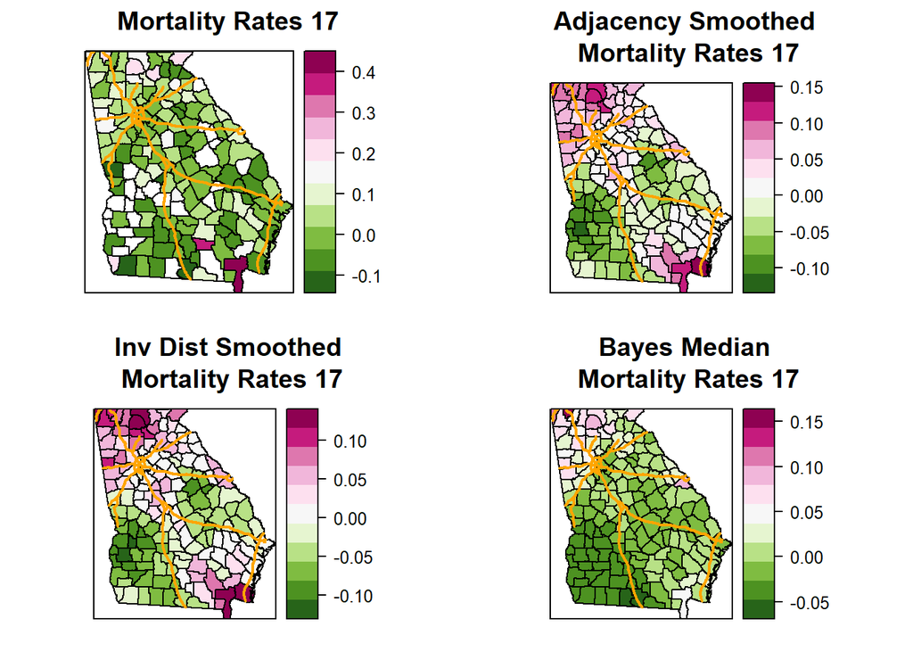

```r
BayEst <- readxl::read_xlsx(here("Data", "BayesEstimates.xlsx"))

gaCounty_df$MortRateBayes <- BayEst$BayesMedianMu / gaCounty_df$Population * 1000

ps_b <- spplot_ga("MortRateBayes", "Bayes Median\n Mortality Rates 17")

gridExtra::grid.arrange(p, ps, ps_i, ps_b, ncol = 2)
```